# Week 6 Learning Journal

Published

February 14, 2024

## Section 1: Geo-processing and Overlay Analysis

Tutorial name(s) and link(s):

- [Predict Deforestation in the Amazon Rain Forest](https://learn.arcgis.com/en/projects/predict-deforestation-in-the-amazon-rain-forest/#finish-and-print-the-map) (Approx 1 hour)

Insight: ArcGIS provides and extensive array of tools and processes to combine and join data in many ways, there is almost always a ‘best’ tool for the job since many are specifically designed for a specific purpose. Taking the time to understand you current features, your question, and what you need to to answer you question can save you a huge headache later.

Screenshot(s):

Impact of Proposed Road in Brazil

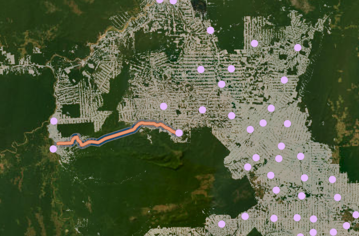

### Essential Geoprocessing Table

| **Tool** | **What it does** | **Example** |
| --- | --- | --- |
| Buffer | Creates a new feature layer where each feature is a specified distance away from the original features. | Generating a 500-meter buffer around all rivers to delineate a protected area. |
| Calculate Geometry | Allows for the calculation of geometric properties (such as area, length, or coordinates) of features within a layer. | Calculating the area of each polygon in a land use dataset. |
| Clip | Cuts out a portion of one feature layer using the shape of another layer as the boundary. | Clipping a national forest layer to the boundaries of a specific state. |
| Create feature class from a selection | Creates a new feature class by copying only the selected portion of a given feature class. | Create a ‘Wasatch Area’ class by selecting the 5 wasatch counties and creating a feature class from this selection. |
| Definition Query | Filters data in a layer by applying an SQL query | Layer has values from 1900-2023, but we only want values pre-1965, a DQ can be applied with this logic. |
| Dissolve | Aggregates features based on specified attributes, removing boundaries to create a new layer of larger, simplified polygons. | Dissolving a county-level map into a state-level map by merging all counties within each state. |
| Erase | Creates a feature class by overlaying the input features with the polygons of the erase features | Select only a portion of a feature class by excluding a section of overlap |
| Geocoding | Convert addresses into geographic coordinates or vice versa, enabling the mapping and analysis of address-based data. | Transform a list of addresses into a map layer of points representing their locations. |
| Intersect | Computes a geometric intersection of the input features | Points within a polygon |
| Merge | Combines multiple input datasets into a single, new output dataset. | Merging separate layers of lakes, rivers, and ponds into a single water bodies layer. |
| Points to lines | Converts a set of points into a line feature by connecting them based on their order or an attribute value. | Create a hiking trail line feature from a series of GPS waypoints collected along the trail. |
| Select by location | Selects features in a layer based on their spatial relationship to features in another layer. | Selecting all buildings within 1 kilometer of a river. |
| Select by attribute | Selects features in a layer based on a query applied to their attributes. | Selecting all cities with a population greater than 100,000. |
| Spatial Join | Joins attributes from one feature to another based on the spatial relationship | Grab data from one class to another |
| Summarize within | Aggregates data from one layer within the boundaries of another layer, summarizing the information. | Calculating the total population within each zip code area by summarizing individual household data. |
| Union | Computes a geometric union of the input features | join features but maintain integrity of original boundaries. |

### Statements of Understanding

- Create a new feature class from a selection (This is an important skill that you will use many times).
  - Right click feature, ‘Data’, ‘Export Features’
- Find linear units of measure for a coordinate system.
  - Calculate Geometry tool (analysis tool)
- Calculate fields in the attribute table.
  - Open att. table, ‘calculate field’, can use python here.
- Use Trace in the editing tools.
  - The snapping section of this tutorial was great, would’ve been nice to understand when we did the girls camp challenge.

## Section 2: Data Sources

Knowing where to find and download geospatial data can be a big challenge. In this section, list the internet data sources that you use during the semester and any others that you encounter on your own.

- ESRI Tutorial Download

## Section 3: Class How To’s

In this section include documents provided in class (e.g., how to prepare a table for use in GIS, how to georeference) or notes about a specific tool you learn about that’s not part of the assigned topics.

N/A